# Inheritance

- In Short: Deriving class from an existing class

## Inheritance Philosophy

We achiece reusability in out code, by borrowing features from parent child, into child class

```
class Rectangle{}

class Cuboid: public Rectangle{}
```

All data members and functions from **Base** class are shared by the "child" or **Derived** class

The Derived class access to Base class's member* is only limited by **Access Specifiers** (more about this later)

Thats is :

```
private
protected
public
```

The flow of calls (not execution) always starts at Base Class, then to Derived Class, where execution occurs. (more about this later)

### Cnstructors

```
class Base{
public:
    Base(){
        cout<<"Default Base"<<endl;
    }

    Base(int x){
        cout<<"Parameterized Base "<<x<<endl;
    }

}

class Derived: Base{
public:
    Derived(){
        cout<<"Default Derived"<<endl;
    }

    Derived(int y){
        cout<<"Parameterized Derived "<<y<<endl;
    }

}
```

As indicated flow goes from parent to child, that means first the Base Constructor is called, then the Derived Constructor

[**OUTPUT**]

```
Derived d;

Default Base
Default Derived
```

How does the parameterised of Derived will work. First the Default of Base is called, then Param of Derived is called

[**OUTPUT**]

```
Derived D(10);

Default Base
Parameterized Derived 10
```

So for (when called) Default and Param of Derived, The Defualt Constructer in both cases will be exucuted first.

But what is I want the Param of Base (not Default Base) to be called, when Param of Derived is called? How is this achieved?

We need a special constructor for Derived: How do we read it?

We pass two arguments, one for base (x), other is for Derived(y).

But how do we get x to Base? we write, `:Base (x)`

```
Derived (int x, int y) : Base (x){
        cout<<"Param of  Derived "<<y<<endl;
    }
}
```

[**OUTPUT**]

```
Parameterized Base 10
Param of  Derived 20
```

Now the param of Base is called first, value (x) gotton from Derived,then Param of Derived is called.

That is Param Base is called from Param Derived.

### Is-a and has-a

**Is-a** is used for Parent-child relationship where you have a Base and Derived Class

**Has-a** is used where you using one class inside another

These are the two ways a class can be used:

1. Derived from another class(Parent-child) (is-a)
2. Having an object of one class, inside another (has-a)

### Access Specifiers

We have the following Access Specifiers:

```
private
protected
public
```

```
class Base{
private:
  int a;
protected:
  int b;
public:
  int c;

  void funBase(){
        a=10;
        b=20;
        c=30;
    }
}
```

[**OUTPUT**]

```
Base x;
x.a=10;  [Not possible]
x.b=20;  [Not possible]
x.c=30;  [Possible]
```

But the access specifiers become more complex, when you dealing wih Parent-Child (Inherited) Classes.

**Here are the RULES (easy):**

1. Outside the class, only public members are accessible
2. Inherited classes: protected and public is accessible between parent and child

**Heree are the RULES (hard):** Given: private is ONLY accessible to class itself

1. public Parent (this is default one)

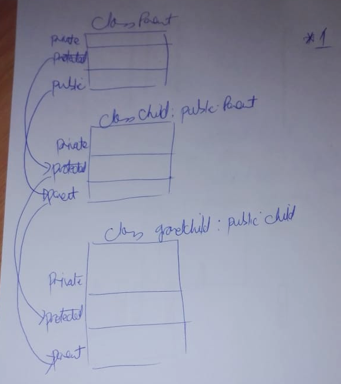

From Parent to Child: protected becomes proctected public becomes public

From Child to Grandchild: Grandchild have access to parent and child (protected and public)

1. protected Parent

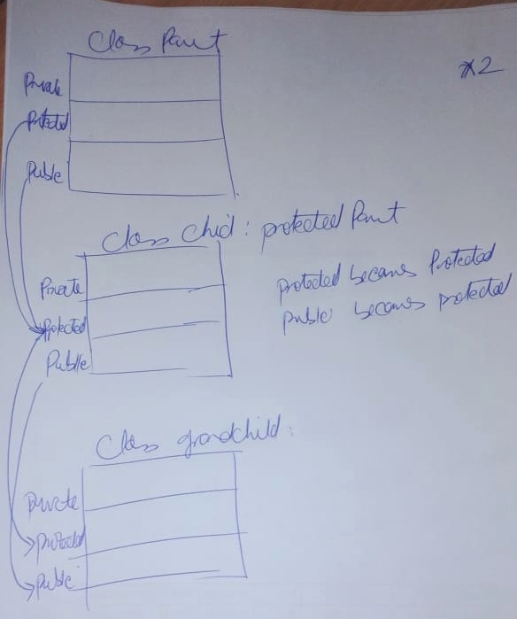

From Parent to Child: protected becomes proctected public becomes protected

From Child to Grandchild: Grandchild still have access to parent and child (protected and public)

1. private Parent

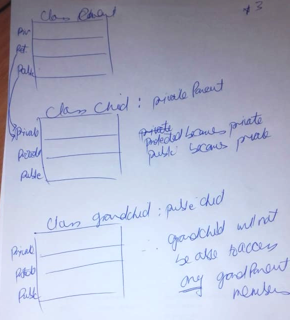

From Parent to Child: protected becomes private public becomes private

From Child to Grandchild: Grandchild has NO ACCESS to parent (GrandParent)

### Types of Inheritance

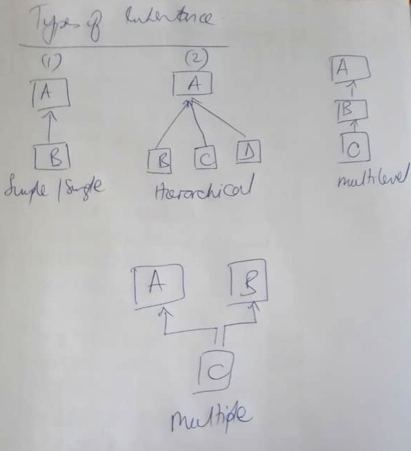

**Single/Simple** Class inherits from single class

**Herarchical** More than one class is inheriting from one class Here the parent class is a general(ised) class

**Multilevel** Inherit from one class through intermediate class

**Multiple** Class can inherit from more than one class

**Hybrid (Missing Hieratchical and Multiple)**

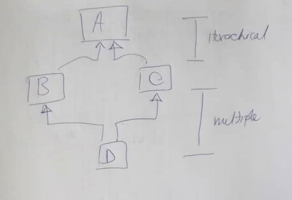

D inherits from A through B and C

This is called Multipart Inheritance, D gets copy of A, via B or via C. Which is the correct one...i.e. But this is a problem (ambiguity).

To remove this ambiguity, we have concept of **virtual base classes**

```
class A{}

class B: virtual public A

class C: virtual public A

class D: public B, public C
```